[figure not shown]

# House Prices - advanced regression techniques

It is often said that: first impressions count! As data scientists, we might then ask what first impressions are made of? Certainly, when looking for a new home the overall appearance of a house plays a big role. But what about the veneer type of the kitchen cabinets or the size of the bath? There are many factors which may influence a purchase. Using a dataset with 79 variables describing homes in Ames, Iowa, we'll look at what really drives house sales.

In this exploration, we will analyze data on house sales and apply advanced regression techniques to answer the following questions:

- Which factors influence house prices the most?
- Which neighborhoods if any are most attractive?
- Which factors are detrimental to a sales price?
- Finally, can we predict the sales price of a house with reasonable accuracy?

## Importing libraries

We start by importing the libraries needed for our data analysis.

```python
# We will use the pandas framework for data munging
import pandas as pd
pd.set_option('display.max_rows', 200)
pd.set_option('display.max_columns', 500)
pd.set_option('display.width', 1000)

import math

import numpy as np

from scipy import stats
from scipy.stats import skew, norm

from sklearn.model_selection import cross_val_score
from sklearn.preprocessing import StandardScaler

# Matplotlib, used through Seaborn, is our main library for displaying graphs
%matplotlib inline
%config InlineBackend.figure_format = 'retina'

import matplotlib
import matplotlib.pyplot as plt
import seaborn as sns

# We use folium for displaying predicted house prices on a map
import folium
from folium.features import DivIcon
import colorsys
```

## Importing data

We will be analyzing the [Ames Housing](http://ww2.amstat.org/publications/jse/v19n3/decock.pdf) dataset that was compiled by **Dean De Cock**. It describes the sale of individual residential property in **Ames, Iowa** from **2006 to 2010** and contains **2919** observations.

```python
train = pd.read_csv('input/train.csv', header=0, index_col=0)
test = pd.read_csv('input/test.csv', header=0, index_col=0)
alldata = pd.concat((train.loc[:,'MSSubClass':'SaleCondition'],
                     test.loc[:,'MSSubClass':'SaleCondition']))
```

## A first look

```python
print(train.shape)
print(test.shape)
```

```
(1460, 80)
(1459, 79)
```

We find **2919** observations in total, described by **79** independent variables and one **1** target variable called *'SalePrice'*. Note that the test set does not contain any sales price. Based on the number variables, we must be careful in choosing a suitable regression model.

```python
alldata.head(10)
```

| Id | MSSubClass | MSZoning | LotFrontage | LotArea | Street | Alley | LotShape | LandContour | Utilities | LotConfig | LandSlope | Neighborhood | Condition1 | Condition2 | BldgType | HouseStyle | OverallQual | OverallCond | YearBuilt | YearRemodAdd | RoofStyle | RoofMatl | Exterior1st | Exterior2nd | MasVnrType | MasVnrArea | ExterQual | ExterCond | Foundation | … |
| --- | --- | --- | --- | --- | --- | --- | --- | --- | --- | --- | --- | --- | --- | --- | --- | --- | --- | --- | --- | --- | --- | --- | --- | --- | --- | --- | --- | --- | --- | --- |
| 1 | 60 | RL | 65.0 | 8450 | Pave | NaN | Reg | Lvl | AllPub | Inside | Gtl | CollgCr | Norm | Norm | 1Fam | 2Story | 7 | 5 | 2003 | 2003 | Gable | CompShg | VinylSd | VinylSd | BrkFace | 196.0 | Gd | TA | PConc | … |
| 2 | 20 | RL | 80.0 | 9600 | Pave | NaN | Reg | Lvl | AllPub | FR2 | Gtl | Veenker | Feedr | Norm | 1Fam | 1Story | 6 | 8 | 1976 | 1976 | Gable | CompShg | MetalSd | MetalSd | None | 0.0 | TA | TA | CBlock | … |
| 3 | 60 | RL | 68.0 | 11250 | Pave | NaN | IR1 | Lvl | AllPub | Inside | Gtl | CollgCr | Norm | Norm | 1Fam | 2Story | 7 | 5 | 2001 | 2002 | Gable | CompShg | VinylSd | VinylSd | BrkFace | 162.0 | Gd | TA | PConc | … |
| 4 | 70 | RL | 60.0 | 9550 | Pave | NaN | IR1 | Lvl | AllPub | Corner | Gtl | Crawfor | Norm | Norm | 1Fam | 2Story | 7 | 5 | 1915 | 1970 | Gable | CompShg | Wd Sdng | Wd Shng | None | 0.0 | TA | TA | BrkTil | … |
| 5 | 60 | RL | 84.0 | 14260 | Pave | NaN | IR1 | Lvl | AllPub | FR2 | Gtl | NoRidge | Norm | Norm | 1Fam | 2Story | 8 | 5 | 2000 | 2000 | Gable | CompShg | VinylSd | VinylSd | BrkFace | 350.0 | Gd | TA | PConc | … |
| 6 | 50 | RL | 85.0 | 14115 | Pave | NaN | IR1 | Lvl | AllPub | Inside | Gtl | Mitchel | Norm | Norm | 1Fam | 1.5Fin | 5 | 5 | 1993 | 1995 | Gable | CompShg | VinylSd | VinylSd | None | 0.0 | TA | TA | Wood | … |
| 7 | 20 | RL | 75.0 | 10084 | Pave | NaN | Reg | Lvl | AllPub | Inside | Gtl | Somerst | Norm | Norm | 1Fam | 1Story | 8 | 5 | 2004 | 2005 | Gable | CompShg | VinylSd | VinylSd | Stone | 186.0 | Gd | TA | PConc | … |
| 8 | 60 | RL | NaN | 10382 | Pave | NaN | IR1 | Lvl | AllPub | Corner | Gtl | NWAmes | PosN | Norm | 1Fam | 2Story | 7 | 6 | 1973 | 1973 | Gable | CompShg | HdBoard | HdBoard | Stone | 240.0 | TA | TA | CBlock | … |
| 9 | 50 | RM | 51.0 | 6120 | Pave | NaN | Reg | Lvl | AllPub | Inside | Gtl | OldTown | Artery | Norm | 1Fam | 1.5Fin | 7 | 5 | 1931 | 1950 | Gable | CompShg | BrkFace | Wd Shng | None | 0.0 | TA | TA | BrkTil | … |
| 10 | 190 | RL | 50.0 | 7420 | Pave | NaN | Reg | Lvl | AllPub | Corner | Gtl | BrkSide | Artery | Artery | 2fmCon | 1.5Unf | 5 | 6 | 1939 | 1950 | Gable | CompShg | MetalSd | MetalSd | None | 0.0 | TA | TA | BrkTil | … |

A quick look at the data reveals that many variables have missing data. In addition, we see a blend of numerical, nominal, ordinal variables. These will all be have to dealt with using appropriate imputations and transformations.

We also make sure the variables have an appropriate data type:

```python
alldata.dtypes
```

```
MSSubClass         int64
MSZoning          object
LotFrontage      float64
LotArea            int64
Street            object
Alley             object
LotShape          object
LandContour       object
Utilities         object
LotConfig         object
LandSlope         object
Neighborhood      object
Condition1        object
Condition2        object
BldgType          object
HouseStyle        object
OverallQual        int64
OverallCond        int64
YearBuilt          int64
YearRemodAdd       int64
RoofStyle         object
RoofMatl          object
Exterior1st       object
Exterior2nd       object
MasVnrType        object
MasVnrArea       float64
ExterQual         object
ExterCond         object
Foundation        object
BsmtQual          object
BsmtCond          object
BsmtExposure      object
BsmtFinType1      object
BsmtFinSF1       float64
BsmtFinType2      object
BsmtFinSF2       float64
BsmtUnfSF        float64
TotalBsmtSF      float64
Heating           object
HeatingQC         object
```

[output cut: 25 more lines]

```
WoodDeckSF         int64
OpenPorchSF        int64
EnclosedPorch      int64
3SsnPorch          int64
ScreenPorch        int64
PoolArea           int64
PoolQC            object
Fence             object
MiscFeature       object
MiscVal            int64
MoSold             int64
YrSold             int64
SaleType          object
SaleCondition     object
dtype: object
```

## Univariate Analysis

### SalePrice

*'SalePrice'* is the target variable that we wish to predict.

```python
train['SalePrice'].describe()
```

```
count      1460.000000
mean     180921.195890
std       79442.502883
min       34900.000000
25%      129975.000000
50%      163000.000000
75%      214000.000000
max      755000.000000
Name: SalePrice, dtype: float64
```

The descriptive statistics summary shows that the minimum price is larger than zero. We also seem to have a maximum price outside the upper quartile indicating the possible presence of outliers.

We now check if the variable follows a normal distribution. This is important because several statistic tests (e.g. t-statistics) rely on this.

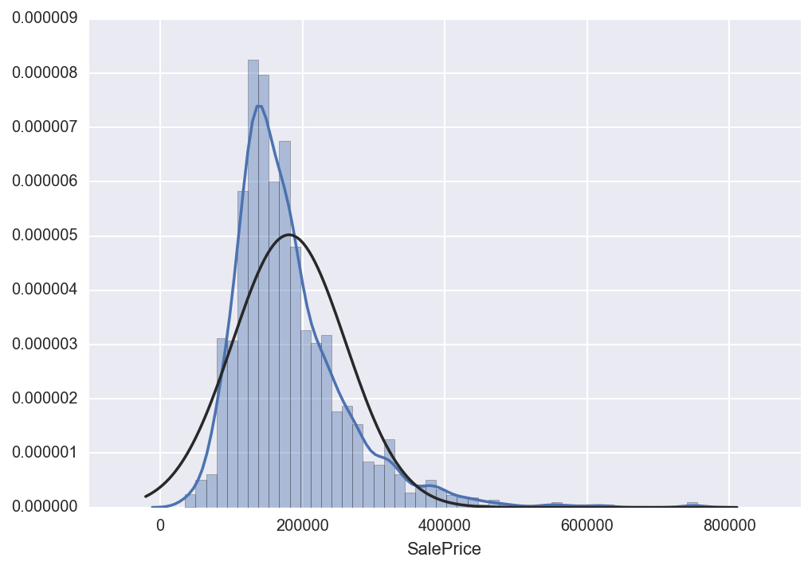

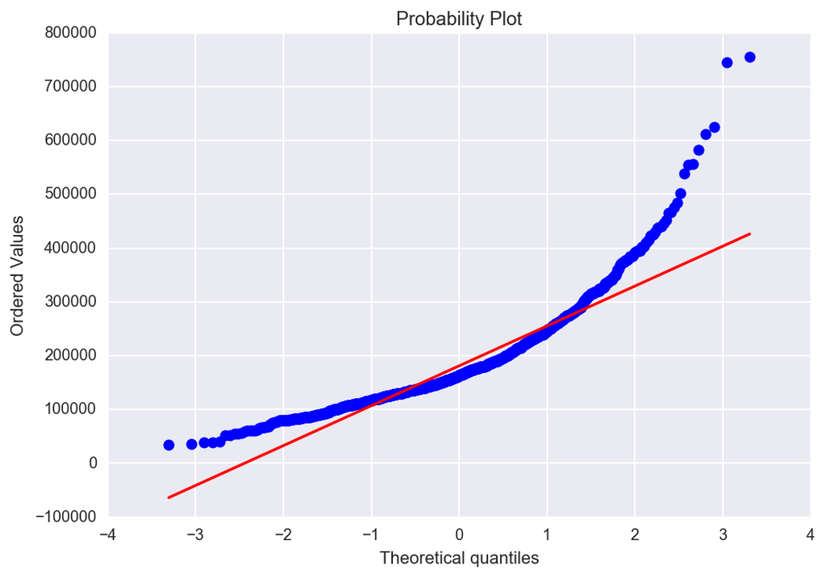

```python
sns.distplot(train['SalePrice'], fit=norm);
fig = plt.figure()
res = stats.probplot(train['SalePrice'], plot=plt)
```

```python
print("Skewness: %f" % train['SalePrice'].skew())
print("Kurtosis: %f" % train['SalePrice'].kurt())
```

```
Skewness: 1.882876
Kurtosis: 6.536282
```

The histogram above shows that SalePrice doesn't follow normal distribution and is skewed right, before performing regression it has to be transformed. We will apply a log transformation to deal with this situation.

## Multivariate analysis

To reduce confounders, only variables uncorrelated with each other (and correlated with SalePrice) should be added to regression models. We therefore look for multicollinearity in our dataset.

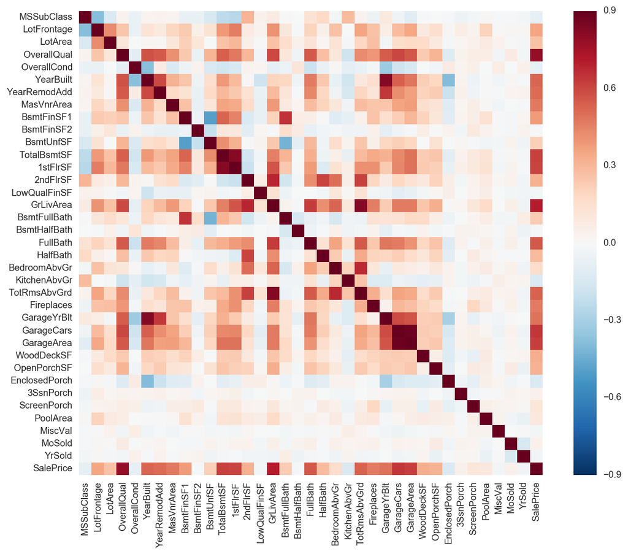

```python
correlation_matrix = train.corr()
fig, ax = plt.subplots(figsize=(12, 9))
sns.heatmap(correlation_matrix, vmax=.9, square=True);
```

Our correlation matrix, visualized on a heatmap, shows there are many strong correlations between variables. As an example, Garage area is strongly correlated with the number of cars, and at the same time both are strongly correlated with the sales price.

There are at least three ways to deal with this issue:

- Remove confounding variables
- Use feature engineering
- Apply dimensionality reduction, reducing the dataset to a smaller number of non-collinear variables.

We now look at the top 10 variables most correlated with *'SalePrice'*:

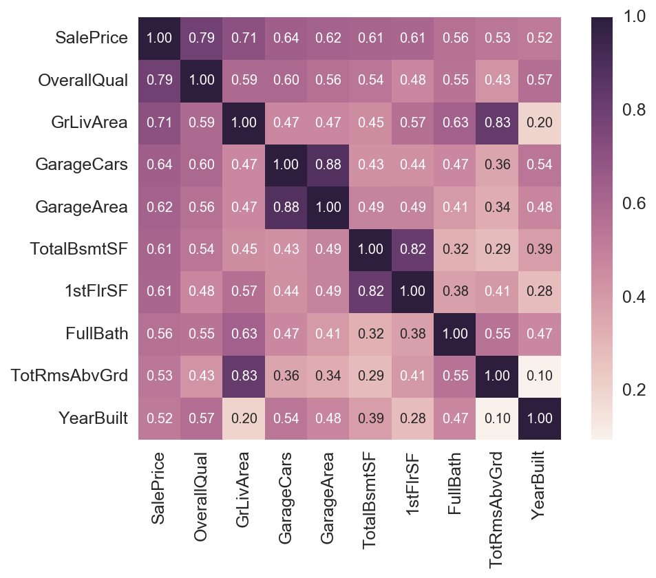

```python
n = 10 # Number of variables
columns = correlation_matrix.abs().nlargest(n, 'SalePrice')['SalePrice'].index
correlation_coefficients = np.corrcoef(train[columns].values.T)
sns.set(font_scale=1.25)
hm = sns.heatmap(correlation_coefficients, cbar=True, annot=True, square=True, fmt='.2f', annot_kws={'size': 10}, yticklabels=columns.values, xticklabels=columns.values)
plt.show()
```

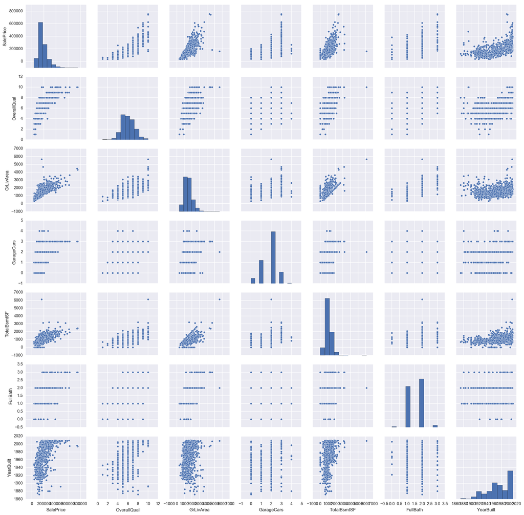

```python
sns.set()
columns = ['SalePrice', 'OverallQual', 'GrLivArea', 'GarageCars', 'TotalBsmtSF', 'FullBath', 'YearBuilt']
sns.pairplot(train[columns], size = 2.5)
plt.show();
```

We see some non-linear relations with *'SalePrice'*, e.g. *'YearBuilt'*. These may be handled by adding them through some transformation(quadratic etc.) to our regression model. Also note the heteroscedasticity with *'GrLivArea'* and *'TotalBsmmntSF'* in relation to *'SalePrice'*.

## Imputations

Missing values often have a negative effect on regression/classification models. In addition, some machine learning algorithms, such as Support Vector Machines, can't deal with missing data.

One way of dealing with missing values is to use the mean/mode of the variable to predict the missing values using a regression/classification model. However, being predictions themselves these approaches are not 100% accurate.

```python
total = alldata.isnull().sum().sort_values(ascending=False)
percent = (alldata.isnull().sum()/alldata.isnull().count()).sort_values(ascending=False)
missing_data = pd.concat([total, percent], axis=1, keys=['Missing', 'Missing/Total'])
missing_data.head(20)
```

|  | Missing | Missing/Total |
| --- | --- | --- |
| PoolQC | 2909 | 0.996574 |
| MiscFeature | 2814 | 0.964029 |
| Alley | 2721 | 0.932169 |
| Fence | 2348 | 0.804385 |
| FireplaceQu | 1420 | 0.486468 |
| LotFrontage | 486 | 0.166495 |
| GarageCond | 159 | 0.054471 |
| GarageQual | 159 | 0.054471 |
| GarageYrBlt | 159 | 0.054471 |
| GarageFinish | 159 | 0.054471 |
| GarageType | 157 | 0.053786 |
| BsmtCond | 82 | 0.028092 |
| BsmtExposure | 82 | 0.028092 |
| BsmtQual | 81 | 0.027749 |
| BsmtFinType2 | 80 | 0.027407 |
| BsmtFinType1 | 79 | 0.027064 |
| MasVnrType | 24 | 0.008222 |
| MasVnrArea | 23 | 0.007879 |
| MSZoning | 4 | 0.001370 |
| BsmtHalfBath | 2 | 0.000685 |

We will drop all variables having at least ~15% missing data. These variables have a small affect on *'SalePrice'*, as supported by our previous multivariate analysis.

```python
alldata.drop(['PoolQC', 'MiscFeature', 'Alley', 'Fence', 'FireplaceQu', 'LotFrontage'], axis=1, inplace=True)
```

### Garage

We will assume that the garage wasn't built before the house. For the remaning variables, we will assume that NaN's indicate a missing feature or represent some other value.

```python
# Assume NaN means no garage
alldata.GarageCond.fillna('NoGarage', inplace=True)
alldata.GarageQual.fillna('NoGarage', inplace=True)
alldata.GarageFinish.fillna('NoGarage', inplace=True)
alldata.GarageType.fillna('NoGarage', inplace=True)

# Assume garage was built after house
missing = alldata.GarageYrBlt.isnull()
alldata.loc[missing, 'GarageYrBlt'] = alldata.loc[missing, 'YearBuilt']
```

### Basement

```python
# Assume NaN means no basement
alldata.BsmtCond.fillna('NoBasement', inplace=True)
alldata.BsmtExposure.fillna('NoBasement', inplace=True)
alldata.BsmtQual.fillna('NoBasement', inplace=True)
alldata.BsmtFinType2.fillna('NoBasement', inplace=True)
alldata.BsmtFinType1.fillna('NoBasement', inplace=True)
alldata.BsmtHalfBath.fillna('NoBasement', inplace=True)
```

### Masonry

```python
# Assume NaN means 'other'
alldata.MasVnrType.fillna('Other', inplace=True)

# Assume NaN means 0
alldata.MasVnrArea.fillna(0, inplace=True)
```

### Simple handling of other variables with missing data

We replace the NaN's in the remaning numerical variables using the mean value of the variable.

```python
alldata = alldata.fillna(alldata.mean())
```

## Transformations

### SalePrice

Our previous univariate analysis showed *'Saleprice'* having a positive skewness. Since there are no minimum values of zero, we apply a simple log transform. This also has the benefit of handling outliers.

```python
# Positive skewness - apply a log transform
train['SalePrice'] = np.log(train['SalePrice'])
```

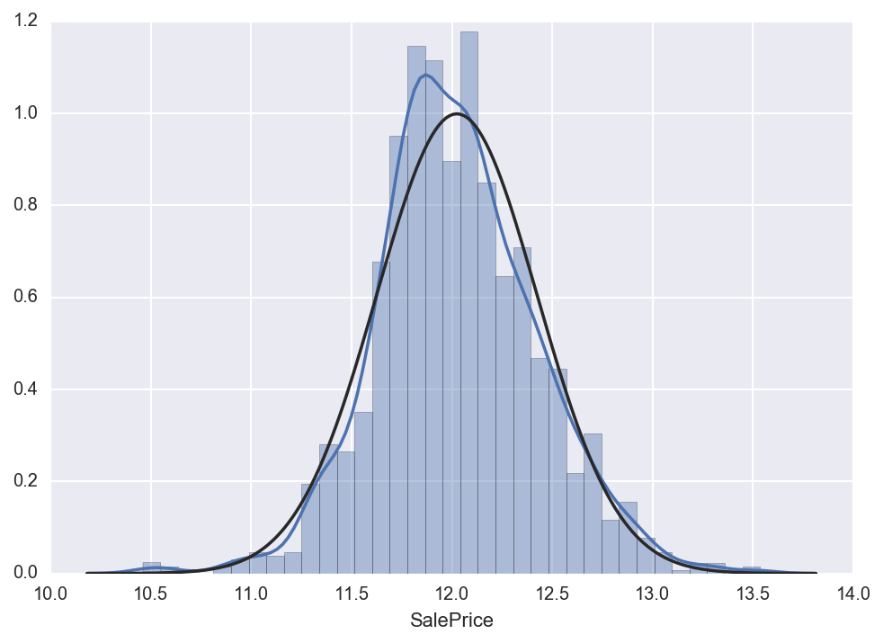

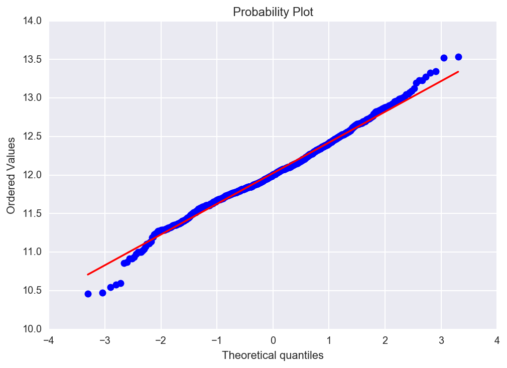

```python
sns.distplot(train['SalePrice'], fit=norm);
fig = plt.figure()
res = stats.probplot(train['SalePrice'], plot=plt)
```

### OverallQual

We then perform a similar analysis on the two variables most correlated to *'SalePrice'* - Overall quality and grand living area.

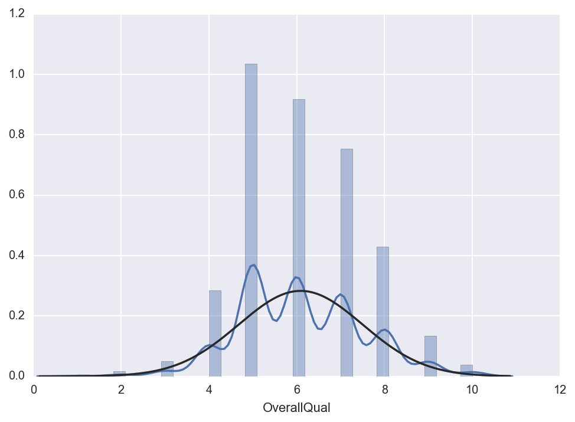

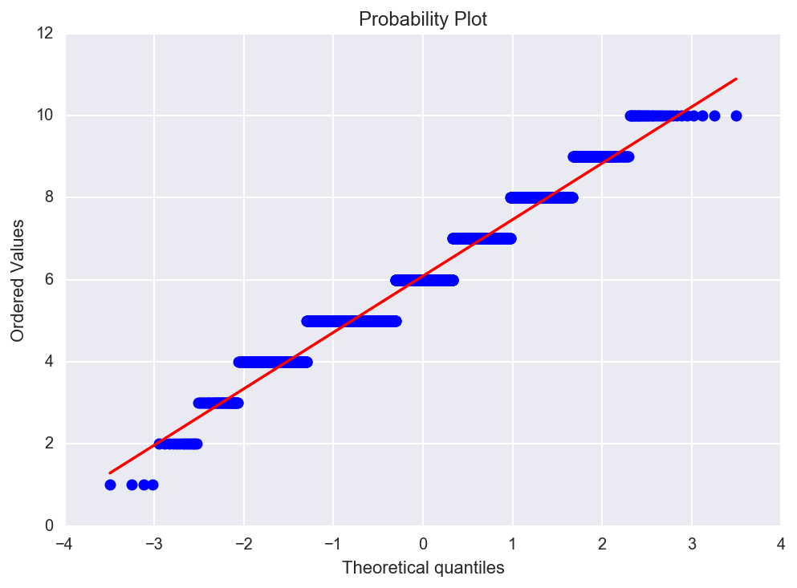

```python
sns.distplot(alldata['OverallQual'], fit=norm);
fig = plt.figure()
res = stats.probplot(alldata['OverallQual'], plot=plt)
```

```python
print("Skewness: %f" % train['OverallQual'].skew())
print("Kurtosis: %f" % train['OverallQual'].kurt())
```

```
Skewness: 0.216944
Kurtosis: 0.096293
```

Looks fine!

### GRLivArea

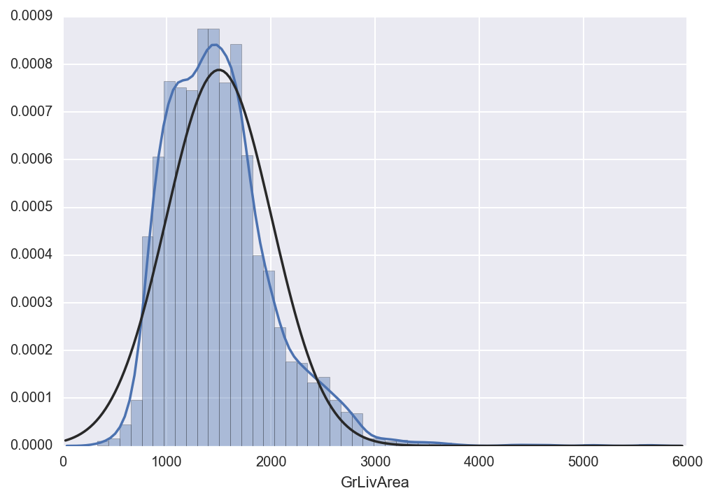

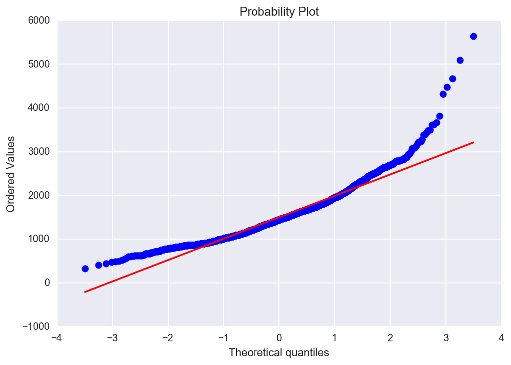

```python
sns.distplot(alldata['GrLivArea'], fit=norm);
fig = plt.figure()
res = stats.probplot(alldata['GrLivArea'], plot=plt)
```

We again find a positive skewness and apply a log transform.

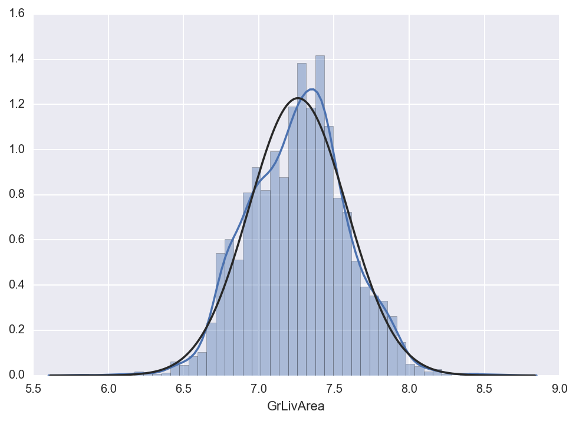

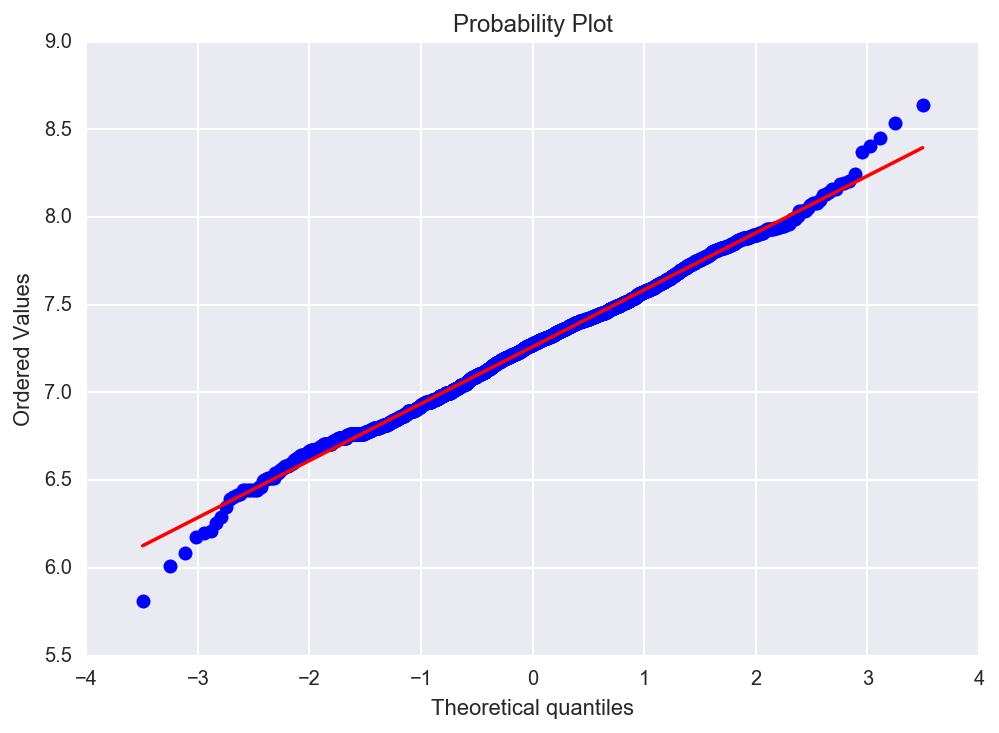

```python
# Log transform
alldata['GrLivArea'] = np.log(alldata['GrLivArea'])

# Transformed histogram and normal probability plot
sns.distplot(alldata['GrLivArea'], fit=norm);
fig = plt.figure()
res = stats.probplot(alldata['GrLivArea'], plot=plt)
```

### Total Basement Square Feet

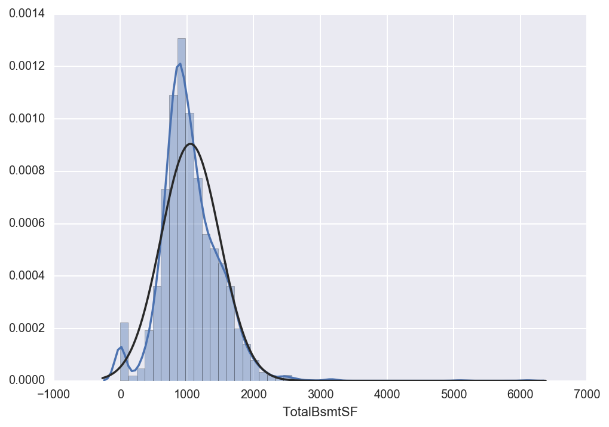

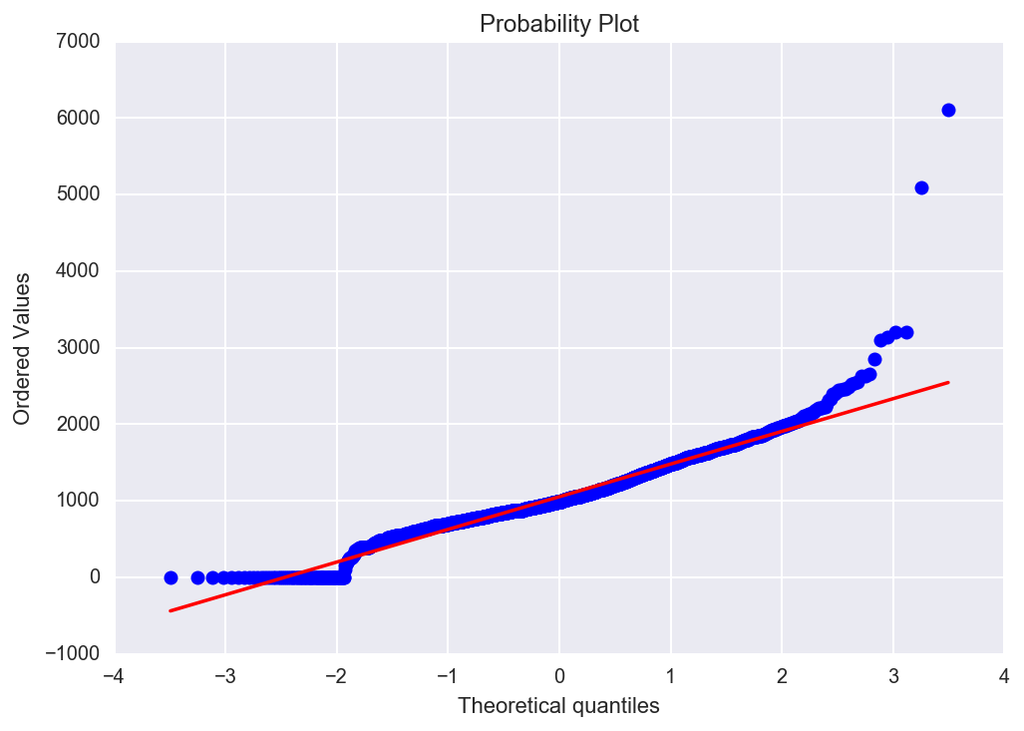

```python
sns.distplot(alldata['TotalBsmtSF'], fit=norm);
fig = plt.figure()
res = stats.probplot(alldata['TotalBsmtSF'], plot=plt)
```

Once again, we find a skewed distribution. Since there are zeros present, we can't simply apply a log transformation. Some more clever engineering is required!

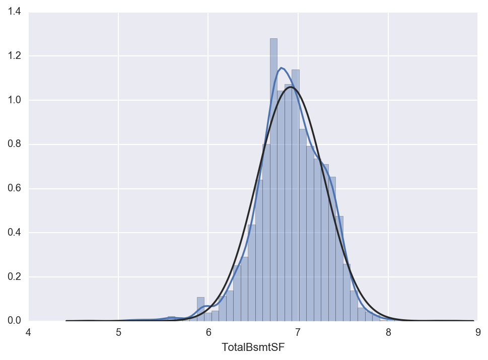

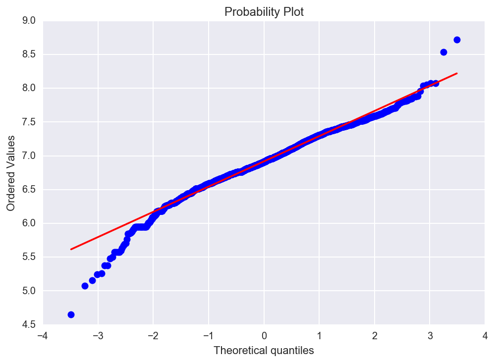

```python
# We create a new variable indicating if the house has a basement
alldata['HasBsmt'] = pd.Series(len(alldata['TotalBsmtSF']), index=alldata.index)
alldata['HasBsmt'] = 0
alldata.loc[alldata['TotalBsmtSF']>0,'HasBsmt'] = 1

# Log transform data if basement exists
alldata.loc[alldata['HasBsmt']==1,'TotalBsmtSF'] = np.log(alldata.loc[alldata['HasBsmt']==1,'TotalBsmtSF'])

# Histogram and normal probability plot
sns.distplot(alldata[alldata['TotalBsmtSF']>0]['TotalBsmtSF'], fit=norm);
fig = plt.figure()
res = stats.probplot(alldata[alldata['TotalBsmtSF']>0]['TotalBsmtSF'], plot=plt)
```

### Transform skewed variables

We check the remaining variables for skewness and apply a log1p transformation as needed.

```python
# Log transform remaining skewed numeric variables:
numeric_columns = alldata.dtypes[alldata.dtypes != "object"].index

# Compute skewness
skewed_features = alldata[numeric_columns].apply(lambda x: skew(x.dropna()))
skewed_features = skewed_features[skewed_features > 0.75]
skewed_features = skewed_features.index

alldata[skewed_features] = np.log1p(alldata[skewed_features])
```

### Simple transform of discrete values

We perform one-hot encoding of discrete values.

```python
alldata = pd.get_dummies(alldata)
```

## Check homoscedasticity

Homoscedasticity refers to the assumption that the dependent variable exhibits equal levels of variance across the range of values of the independent variable. This is a desirable condition because we want a uniform error term.

We will check homoscedasticity using scatter plots; conical, diamond shapes etc. indicate the presence of heteroscedasticity.

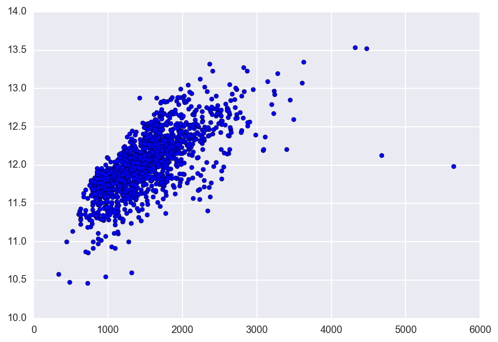

```python
plt.scatter(train['GrLivArea'], train['SalePrice']);
```

## Normalizing variables - StandardScaler

Some machine learning models assume variables have zero mean and unit variance.

```python
alldata[alldata.select_dtypes(['float64']).columns] = StandardScaler().fit_transform(alldata[alldata.select_dtypes(['float64']).columns])
```

## Training and test set

Rather than using a common train/dev/test split, we will evaluate our different approaches using n-fold cross validation on the training set.

```python
X_train = alldata[:train.shape[0]]
X_test = alldata[train.shape[0]:]
y_train = train.SalePrice
```

### Error Metric: Root Mean Square Error (RMSE)

As our error metric, we choose RMSE since it punishes large errors.

```python
nfolds = 5

def score(model, X, y):
    rmse= np.sqrt(-cross_val_score(model, X, y, scoring="neg_mean_squared_error", cv = nfolds))
    return(rmse.mean())
```

## Building models

### Lasso

We will use LASSO as our first regression model as it does both parameter shrinkage and feature selection automatically. We use gridsearch to find the optimal alpha.

```python
from sklearn.linear_model import Lasso
from sklearn.model_selection import GridSearchCV

model = Lasso(max_iter=1e5)
alphas = [1e-4, 1e-3,1e-2, 1, 5, 10]
grid = GridSearchCV(estimator=model, scoring="neg_mean_squared_error", cv=5, param_grid=dict(alpha=alphas)) #, n_jobs=-1

grid.fit(X_train, y_train)

print((-grid.best_score_)**0.5)
print(grid.best_estimator_.alpha)

# Create a LASSO model with best alpha
model = Lasso(alpha = grid.best_estimator_.alpha)
# Do cross validiation using our optimal model
print('RMSE: ' + str(score(model, X_train, y_train)))
model.fit(X_train, y_train)
```

```
0.124070499644
0.001
RMSE: 0.123082892524
```

```
Lasso(alpha=0.001, copy_X=True, fit_intercept=True, max_iter=1000,
   normalize=False, positive=False, precompute=False, random_state=None,
   selection='cyclic', tol=0.0001, warm_start=False)
```

### Modelling Improvements

We keep track on all the improvements (imputations, transformations, etc.) done previously.

| Measure | Lasso |
| --- | --- |
| Baseline (Imputation using mean) | 0.136784828904 |
| Transforming TotalBsmtSF, GrLivArea | 0.135933797421 |
| Simplistic Skewness Adjustment | 0.123632794957 |
| Normalizing variables | 0.123082892524 |

### Feature selection

LASSO automatically does feature selection setting coefficients of variables it deems unimportant to zero. Let's take a look at the coefficients set by LASSO:

```python
coefficients = pd.Series(model.coef_, index = X_train.columns)
print("Lasso selected " + str(sum(coefficients != 0)) + " variables and eliminated the other " +  str(sum(coefficients == 0)) + " variables")
```

```
Lasso selected 72 variables and eliminated the other 211 variables
```

Nice! Let's get an overview of the most important variables according to LASSO:

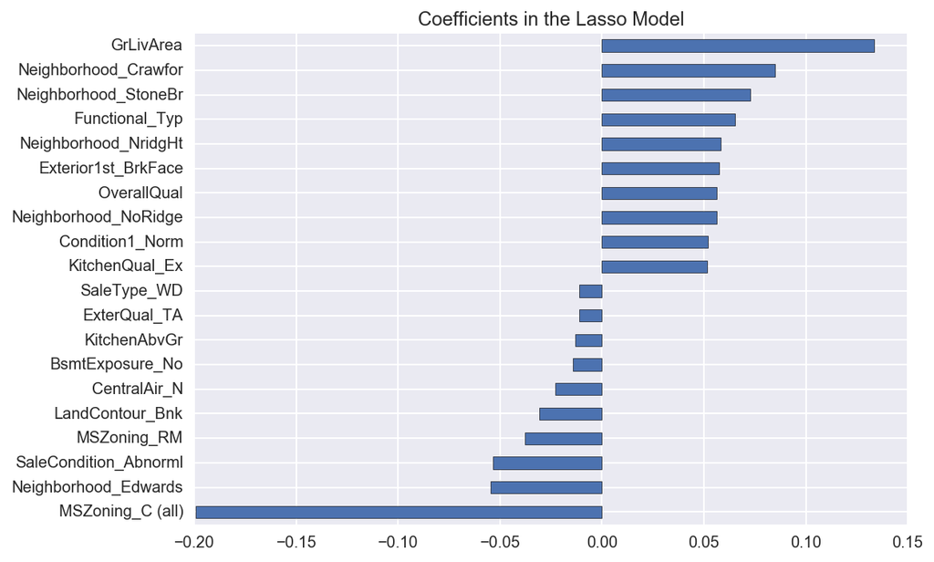

```python
important_coefficients = pd.concat([coefficients.sort_values().head(10),
                     coefficients.sort_values().tail(10)])
important_coefficients.plot(kind = "barh")
plt.title("Coefficients in the Lasso Model")
```

### Residual plot

Let's also take a look at the residuals:

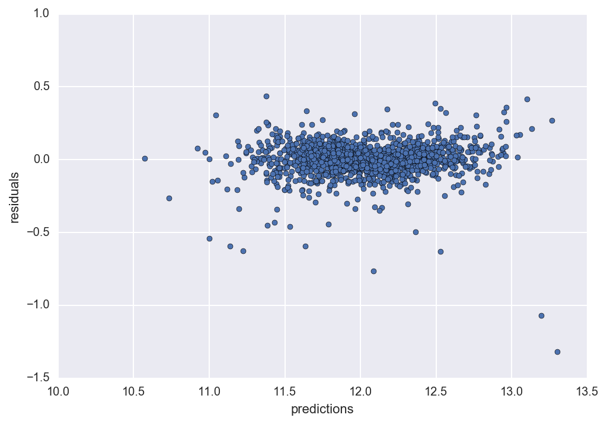

```python
predictions = pd.DataFrame({"predictions":model.predict(X_train), "true":y_train})
predictions["residuals"] = predictions["true"] - predictions["predictions"]
predictions.plot(x = "predictions", y = "residuals",kind = "scatter")
```

The residual plot looks uniform and good!

### Gradient Boosting

Some of the variables in our dataset have many outliers. One benefit of using gradient boosting together with the *huber* loss function is that it provides good robustness to outliers. In addition, by setting max_features to *sqrt* we reduce the overfitting of our model.

```python
from sklearn import ensemble, tree, linear_model
from sklearn.metrics import r2_score, mean_squared_error

model = ensemble.GradientBoostingRegressor(n_estimators=3000, learning_rate=0.05, max_depth=3, max_features='sqrt',
                                               min_samples_leaf=15, min_samples_split=10, loss='huber').fit(X_train, y_train)

print('RMSE: ' + str(score(model, X_train, y_train)))
```

```
RMSE: 0.122723443617
```

We gained a slight improvement over LASSO!

## Predicting house prices

We now turn to predicting the house prices in the test set.

```python
y_test = model.predict(X_test)

X_test = X_test.assign(Prediction=pd.Series(np.exp(y_test)).values)
```

```python
neighborhoods_stacked = X_test.filter(regex=r'^Neighborhood_', axis=1).stack()
neighborhoods = pd.Series(pd.Categorical(neighborhoods_stacked[neighborhoods_stacked!=0].index.get_level_values(1))).apply(lambda x:x.split('_')[1].strip())

X_test = X_test.assign(Neighborhood=pd.Series(neighborhoods).values)
```

```python
locations = pd.read_csv('neighborhoods.csv')

X_test = pd.merge(X_test, locations, how='left', left_on='Neighborhood', right_on='id')
```

### Visualizing predictions

Finally, we plot our predictions on a map.

```python
def floatRgb(mag, cmin, cmax):
    # Normalize to 0-1
    try: x = float(mag-cmin)/(cmax-cmin)
    except ZeroDivisionError: x = 0.5
    HSV = ((x + 1)/2, 1, 1)
    RGB = colorsys.hsv_to_rgb(*HSV)
    return RGB

def rgb(mag, cmin, cmax):
    red, green, blue = floatRgb(mag, cmin, cmax)
    return int(red*255), int(green*255), int(blue*255)

def strRgb(mag, cmin, cmax):
    return "#%02x%02x%02x" % rgb(mag, cmin, cmax)
```

```python
neighborhoods = X_test.groupby(['name', 'lat', 'lon'])['Prediction'].agg({'price': ["count", "mean"]})

map_lat = locations.describe().lat['mean']
map_lon = locations.describe().lon['mean']

house_map = folium.Map(location=[map_lat, map_lon], zoom_start=13)

max_salesprice = neighborhoods.max(numeric_only=True)['price', 'mean']
min_salesprice = neighborhoods.min(numeric_only=True)['price', 'mean']

max_salescount = math.log(neighborhoods.max(numeric_only=True)['price', 'count'])
min_salescount = math.log(neighborhoods.min(numeric_only=True)['price', 'count'])

# Add circlemarkers
for i in neighborhoods.iterrows():
    lat = i[0][1]
    lon = i[0][2]
    priceheat = strRgb(i[1]['price', 'mean'], min_salesprice, max_salesprice)
    countradius = 35 * (math.log(i[1]['price', 'count']) - min_salescount) / (max_salescount - min_salescount)
    fontsize = str(int(32 * (math.log(i[1]['price', 'count']) - min_salescount) / (max_salescount - min_salescount)))
    popup_html = '<h3><center>' + i[0][0] + '</center></h3>' + 'Average sales price: ${:,.2f}'.format(i[1]['price', 'mean'])
    iframe = folium.IFrame(html=popup_html, width=150, height=100)
    popup = folium.Popup(iframe, max_width=2650)

    folium.Marker([lat, lon],
                  icon=DivIcon(
                    icon_size=(1,1),
                    icon_anchor=(countradius/1.4,countradius/1.1),
                    html='<div style="font-size: ' + fontsize + 'pt;font-family: Impact, Arial"><center>' + '{:.0f}'.format(i[1]['price', 'count']) + '</center></div>',
                    )
                 ).add_to(house_map)

    folium.CircleMarker(location=[lat, lon], radius=countradius,
                    popup=popup, color=priceheat,
                    fill_color=priceheat).add_to(house_map)

# Add map title
folium.map.Marker(
    [42.058936037037033, -93.693046777777784],
    icon=DivIcon(
        icon_size=(200,36),
        icon_anchor=(0,0),
        html='<div style="font-size: 24pt;font-family: Brush Script MT">The City of</div>',
        )
    ).add_to(house_map)

folium.map.Marker(
    [42.055936037037033, -93.689046777777784],
    icon=DivIcon(
        icon_size=(200,36),
        icon_anchor=(0,0),
        html='<div style="font-size: 44pt;font-family: Impact, Arial">Ames</div>',
        )
    ).add_to(house_map)

house_map
```

[interactive chart not shown]

- The numbers inside the circles show the number of sales in that neighborhood
- Blue and red colors, indicate respectively, a low and a high average sales price.

## Conclusions

One interesting factor is the exterior material covering the house. A brick face seems to be the most attractive material. Another factor is the zoning classification of the home where a commercial or mixed housing type is least attractive.

We have shown how regression models can be applied and tuned in order to answer our initial questions and predict house prices. One avenue of exploration could be to create a per-neighborhood-model to answer more local questions. This could reveal in which neighborhoods certain characteristics, such as a certain exterior type, are most appreciated.

```python
from IPython.core.display import HTML
def css_styling():
    styles = open("./styles/custom.css", "r").read()
    return HTML(styles)
css_styling()
```

© Copyright 2017, Peter Exner